# Government Tracking Attitudes

Paul M Garrett

7 April 2020

# Report Status

These results represent a snapshot from the first 643 participants collected for the project, Establishing the social licence for Government tracking in Australia. This representative sample was gathered through the data collection platform Dynata.

Notes on cleaning the data.

1. The second and third rows of the raw CSV file were deleted before analysis for ease of loading into R.
2. Sixteen participants were removed prior to analysis for indicating a country of residence other than Australia.
3. Three participants were removed prior to analysis for indicating they were below the age of 18.
4. Participants who did not pass the attention check or who did not complete the survey were removed during pre-processing.

The final sample for analysis was 451 participants.

# Descriptive Statistics

Gender was evenly divided between male and female participants. Within our sample, participants most frequently reported as having a university education (51%) or a higher school education (40%). Ages ranged from 18 years to 84 years (M = 43 years, SD = 17 years). The distribution of reported ages was positively skewed, being overly represented for ages 20–40, and becoming increasingly under-representative for ages 40+.

| Gender identification: Percentages | Gender identification: Percentages #Total |
| --- | --- |
| Gender |  |
| Male | 45.7 |
| Female | 54.1 |
| Other | 0.2 |
| Prefer not to say |  |
| #Total cases | 451 |

| Level of education: Percentages | Level of education: Percentages #Total |
| --- | --- |
| Education |  |
| < High School | 8.6 |
| High School | 40.1 |
| University | 51.2 |
| #Total cases | 451 |

```
## Descriptive Statistics
## COVIDdata$age
## N: 451
##
##                        age
## ----------------- --------
##              Mean    42.73
##           Std.Dev    17.41
##               Min    18.00
##                Q1    28.00
##            Median    39.00
##                Q3    57.00
##               Max    84.00
##               MAD    20.76
##               IQR    29.00
##                CV     0.41
##          Skewness     0.48
##       SE.Skewness     0.11
##          Kurtosis    -1.02
##           N.Valid   451.00
##         Pct.Valid   100.00
```

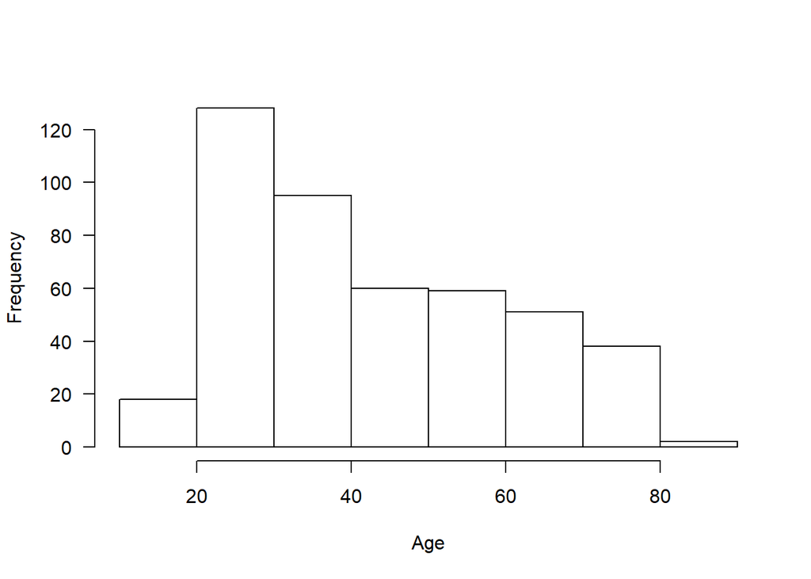

# Impacts of COVID

Participants reported as being under lockdown for 13 (SD = 12) days, with the most frequent amount of time in lockdown reported as zero days (n = 88). Twenty-three percent of participants reported as having lost their job due to COVID-19. The most common source of COVID-19 information came from TV (50%) and newspaper (21%), followed by social media (18%). Of the 451 participants, four reported that they had tested positive with COVID-19, and 36 (8%) indicated they knew someone who had tested positive with COVID-19.

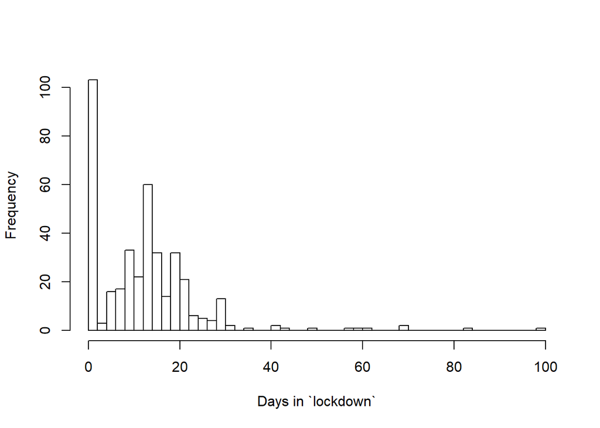

| I have lost my job: Percentages | I have lost my job: Percentages #Total |
| --- | --- |
| I lost my job |  |
| No | 77.2 |
| Yes | 22.8 |
| #Total cases | 451 |

| Information source: Percentages | Information source: Percentages #Total |
| --- | --- |
| Information source |  |
| Newspaper (printed or online) | 20.6 |
| Social media | 18.0 |
| Friends/family | 3.8 |
| Radio | 3.5 |
| Television | 49.9 |
| Other | 4.2 |
| #Total cases | 451 |

| Somebody I know tested positive for COVID-19: Percentages | Somebody I know tested positive for COVID-19: Percentages #Total |
| --- | --- |
| Tested pos someone I know |  |
| No | 92 |
| Yes | 8 |
| #Total cases | 451 |

```r
hist(COVIDdata$COVID_ndays_4, xlab="Days in `lockdown`",main="",  breaks = 50)
```

# Perceived Risk of COVID

When asked about COVID-19 within the Australian population, participants most frequently reported the virus to be moderate in severity and that the virus posed a somewhat harmful risk to their personal health. Responses were both normally distributed around these moderate values.

When asked about their concern over testing positive to COVID-19, participants were normally distributed and centered on moderatly concerned. When asked about their concern over someone they know testing positive to COVID-19, participants responses were negatively skewed, showing a bias in their concerned for the health of others. A strong correlation was observed between concern for others and concern for self (r = .78), and between risk of personal harm and concern for self (r = .64).

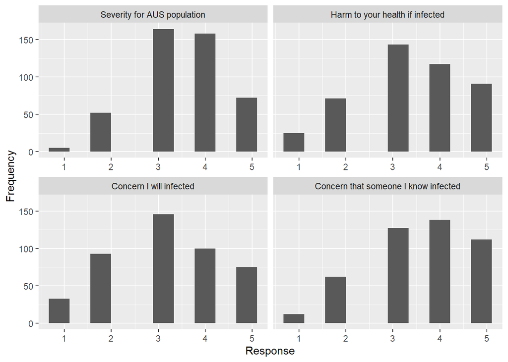

```
##                    COVID_gen_harm COVID_pers_harm COVID_pers_concern
## COVID_gen_harm              1.000           0.479              0.546
## COVID_pers_harm             0.479           1.000              0.638
## COVID_pers_concern          0.546           0.638              1.000
## COVID_concern_oth           0.496           0.495              0.777
##                    COVID_concern_oth
## COVID_gen_harm                 0.496
## COVID_pers_harm                0.495
## COVID_pers_concern             0.777
## COVID_concern_oth              1.000
```

# Perceived Impact of Government Tracking

The following violine plots characterizes participant’s confidence that in each scenario Government tracking would:

1. Reduce their likelihood of contracting COVID-19
2. Allow them to resume their normal lives more rapidly
3. Reduce spread of COVID-19 in the community.

Participants were more confident that they would not contract COVID-19 and that they would resume their normal activities under the severe scenario. Participants were confident that both scenarios would reduce the spread of COVID-19 and higher confidence ratings were generally observed for the severe scenario.

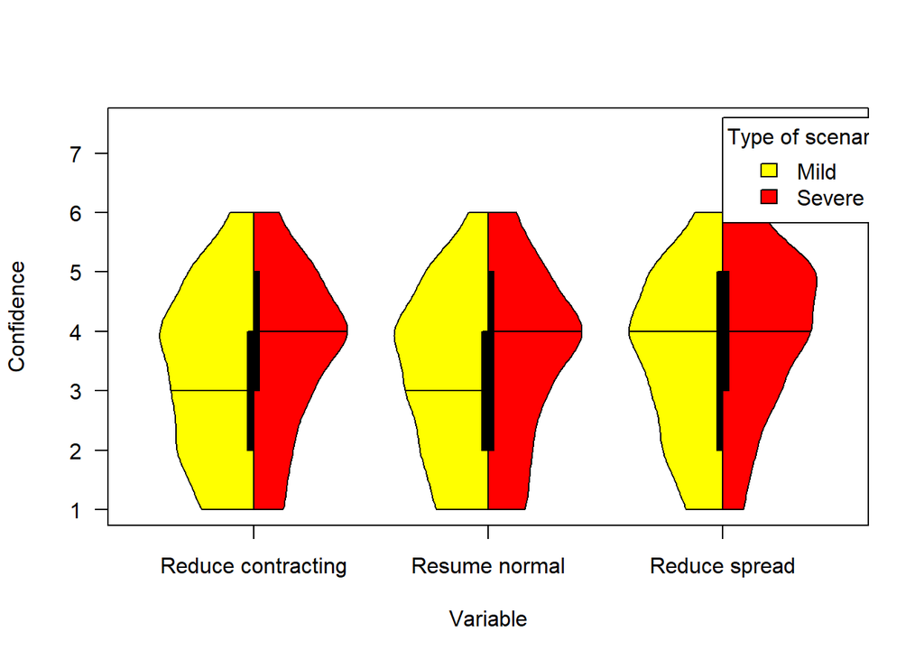

## Acceptability of Government Tracking

The following table displays participant’s acceptability of Government tracking, as probed by a single item immediately after reading the mild or severe scenario. For the mild scenario, the question refers to whether a participant would download the app. For the severe scenario, the question refers to the acceptability of the tracking mandated by government. In both instances, participants generally reported that the measures were acceptable. Against intuitions, acceptability was higher for the severe scenario (79%) than for the mild scenario (71%). These differences did reach statistical significance ($\chi^2$ = 4.11, *p* < .05).

|  |  |  | #Total |
| --- | --- | --- | --- |
| Type of scenario |  |  |  |
| Mild | Acceptability of policy | No | 29.5 |
|  |  | Yes | 70.5 |
|  |  | #Total cases | 234 |
| Severe | Acceptability of policy | No | 20.7 |
|  |  | Yes | 79.3 |
|  |  | #Total cases | 217 |

```
##
##  Pearson's Chi-squared test with Yates' continuity correction
##
## data:  unlabel(accept1$value) and unlabel(accept1$key)
## X-squared = 4.1122, df = 1, p-value = 0.04257
```

The following table displays participant’s acceptability of Government tracking as probed after they have answer a series of questions about the scenario. The general trend in acceptability remains after answering questions about Government tracking, with acceptability being higher for the severe (75%) than for the mild (67%) scenario. These differences did not reach statistical significance ($\chi^2$ = 3.14, *p* = 0.08). Upon reflection, participants were less accepting of Government tracking in both the mild (reduction of 4%) and severe scenarios (reduction of 4%) after answering questions about the described Government tracking.

|  |  |  | #Total |
| --- | --- | --- | --- |
| Type of scenario |  |  |  |
| Mild | Acceptability of policy | No | 32.9 |
|  |  | Yes | 67.1 |
|  |  | #Total cases | 234 |
| Severe | Acceptability of policy | No | 24.9 |
|  |  | Yes | 75.1 |
|  |  | #Total cases | 217 |

```
##
##  Pearson's Chi-squared test with Yates' continuity correction
##
## data:  unlabel(accept2$value) and unlabel(accept2$key)
## X-squared = 3.1364, df = 1, p-value = 0.07656
```

## Conditional Acceptance of Government Tracking

The following results were collected from those people who indicated that they would not download the app (mild scenario) or that the descried tracking was unacceptable (severe scenario).

The following table describes acceptability of Government tracking if a sunset clause were included in the tracking policy, for example, limiting Government tracking to a period of six months after which the data is destroyed. Of those participants who viewed the severe scenario, 41% deemed tracking to be acceptable under a sunset clause, whereas only 20% deemed tracking accepatable under a sunset clause under the mild scenario.

|  |  |  | #Total |
| --- | --- | --- | --- |
| Type of scenario |  |  |  |
| Mild | Acceptability with sunset | No | 80.5 |
|  |  | Yes | 19.5 |
|  |  | #Total cases | 77 |
| Severe | Acceptability with sunset | No | 59.3 |
|  |  | Yes | 40.7 |
|  |  | #Total cases | 54 |

The following tables describe acceptability of Government tracking if i) the tracking data were to stay on the phone and only be uploaded with the consent of the individual (mild scenario only), and ii) if participants were able to opt-into the data collection (severe scenario only).

|  | #Total |
| --- | --- |
| Acceptability with local storage |  |
| No | 71.4 |
| Yes | 28.6 |
| #Total cases | 77 |

|  | #Total |
| --- | --- |
| Acceptability with opt out |  |
| No | 40.7 |
| Yes | 59.3 |
| #Total cases | 54 |

These responses were combined into a quasi-interval scale using the following coding scheme: YES=acceptable; NO=not acceptable unless sunset or optout; -1=not acceptable unless one of sunset or optout (but not the other); -2=not acceptable under any circumstances

|  | #Total |
| --- | --- |
| Acceptability of policy |  |
| -2 | 16.4 |
| -1 | 5.1 |
| No | 7.5 |
| Yes | 71.0 |
| #Total cases | 451 |

The next graph shows responses to the following items (abridged from survey):

1. How easy is it for people to decline participation in the proposed project?
2. To what extent is the Government only collecting the data necessary?
3. How sensitive is the data being collected in the proposed project?
4. How serious is the risk of harm that could arise from the proposed project?
5. How much do you trust the Government to use the tracking data only to deal with the COVID-19 pandemic?
6. How much do you trust the Government to be able to ensure the privacy of each individual?
7. How secure is the data that would be collected for the proposed project?
8. To what extent do people have ongoing control of their data?

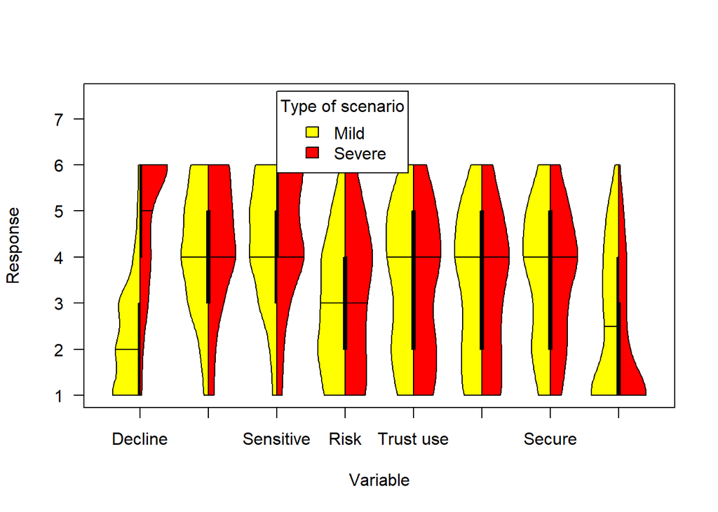

# Influence of World View

We relate a composite of the 3 worldview items to the composite of the 4 items probing perceived risk from COVID. Worldview is scored such that greater values reflect greater libertarianism.

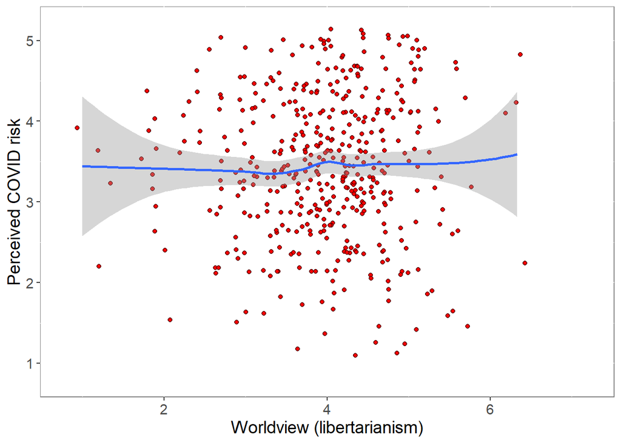

```
##
##  Pearson's product-moment correlation
##
## data:  COVIDdata$Worldview and COVIDdata$COVIDrisk
## t = 0.53564, df = 449, p-value = 0.5925
## alternative hypothesis: true correlation is not equal to 0
## 95 percent confidence interval:
##  -0.06722218  0.11733255
## sample estimates:
##       cor
## 0.0252705
```

Similarly, we relate the composite of the 3 worldview items to the composite of the two trust-in-government items

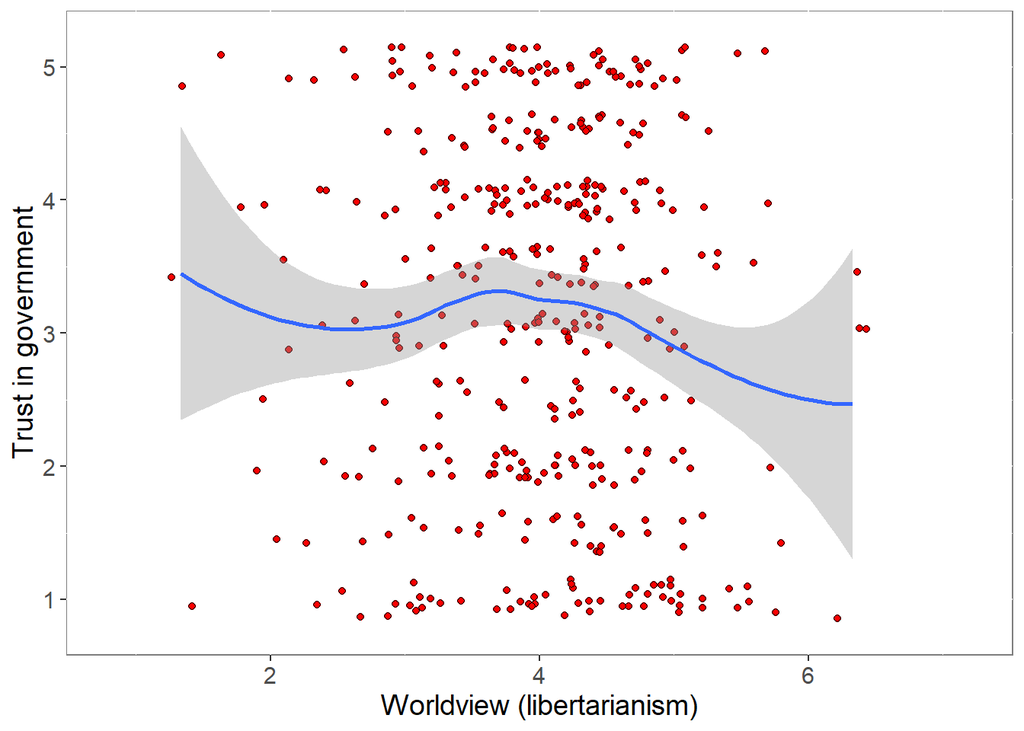

```
##
##  Pearson's product-moment correlation
##
## data:  COVIDdata$Worldview and COVIDdata$govtrust
## t = -2.2241, df = 449, p-value = 0.02664
## alternative hypothesis: true correlation is not equal to 0
## 95 percent confidence interval:
##  -0.19484662 -0.01217037
## sample estimates:
##        cor
## -0.1043889
```